# Cancer Deaths in Hiroshima and Nagasaki Survivors

Joshua Paaske and Lily Karim

Winter 2020

```r
library(tidyverse)
library(dplyr)
library(ggplot2)
```

## Opening file with Fortran format and cleaning up column names

```r
fstr <- c("2I3","I4","F7.1","I5","I4","F10.2","26I4")
hiroshima_nagasaki <- read.fortran("r10cancrfix.dat",fstr)

names(hiroshima_nagasaki) <-  c("city", "sex", "ageatb", "dose_centigray", "time", "index", "total_year", "alldeaths", "alldis", "allneo", "allmal", "leuk", "nonleuk", "digest", "esoph", "stomach", "colon", "rectum", "liver", "gallbldr", "pancreas", "othrdig", "resp", "lung", "fbreast", "fgenital", "cervix", "ovary", "prostate", "urinary", "lymphoma", "myeloma", "othrca")

hiroshima_nagasaki <- hiroshima_nagasaki %>%
  mutate_at(vars(city), ~str_replace_all(., "0", "Hiroshima")) %>%
  mutate_at(vars(city), ~str_replace_all(., "1", "Nagasaki")) %>%
  mutate_at(vars(sex), ~str_replace_all(., "0", "M")) %>%
  mutate_at(vars(sex), ~str_replace_all(., "1", "F")) %>%
  mutate_at(vars(time), ~paste0("19", .)) %>%
  rowid_to_column(var='observation') %>%
  mutate_at(vars(dose_centigray), as.factor) %>%
  mutate_at(vars(ageatb), as.factor)
```

## How many NA’s?

```r
naniar::miss_var_summary(hiroshima_nagasaki)
```

```
## # A tibble: 34 x 3
##    variable       n_miss pct_miss
##    <chr>           <int>    <dbl>
##  1 observation         0        0
##  2 city                0        0
##  3 sex                 0        0
##  4 ageatb              0        0
##  5 dose_centigray      0        0
##  6 time                0        0
##  7 index               0        0
##  8 total_year          0        0
##  9 alldeaths           0        0
## 10 alldis              0        0
## # … with 24 more rows
```

## Tidying Data

```r
tidy_hiroshima_nagasaki <- hiroshima_nagasaki %>%
  pivot_longer(-c(observation, city, sex, ageatb, dose_centigray, time, index, total_year, alldeaths),
               names_to = "type_death",
               values_to = "number_death")

tidy_hiroshima_nagasaki
```

```
## # A tibble: 32,000 x 11
##    observation city  sex   ageatb dose_centigray time  index total_year
##          <int> <chr> <chr> <fct>  <fct>          <chr> <int>      <dbl>
##  1           1 Hiro… M     5      0              1952      1       110.
##  2           1 Hiro… M     5      0              1952      1       110.
##  3           1 Hiro… M     5      0              1952      1       110.
##  4           1 Hiro… M     5      0              1952      1       110.
##  5           1 Hiro… M     5      0              1952      1       110.
##  6           1 Hiro… M     5      0              1952      1       110.
##  7           1 Hiro… M     5      0              1952      1       110.
##  8           1 Hiro… M     5      0              1952      1       110.
##  9           1 Hiro… M     5      0              1952      1       110.
## 10           1 Hiro… M     5      0              1952      1       110.
## # … with 31,990 more rows, and 3 more variables: alldeaths <int>,
## #   type_death <chr>, number_death <int>
```

## Graphs

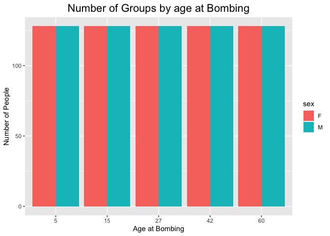

```r
hiroshima_nagasaki %>%
  group_by(sex, ageatb) %>%
  ggplot(aes(x = ageatb, fill = sex)) +
  geom_bar(position = "dodge") +
  labs(title = "Number of Groups by age at Bombing",
       x = "Age at Bombing",
       y = "Number of People")+
  theme(plot.title = element_text(size = rel(1.5), hjust = 0.5))
```

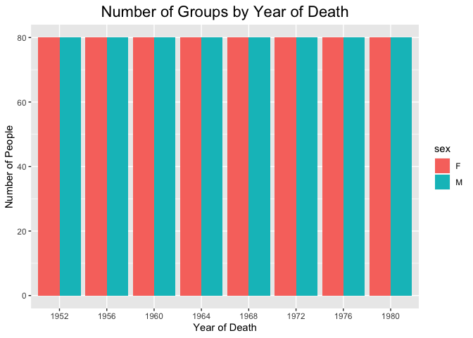

```r
hiroshima_nagasaki %>%
  group_by(sex, time) %>%
  ggplot(aes(x = time, fill = sex)) +
  geom_bar(position = "dodge") +
  labs(title = "Number of Groups by Year of Death",
       x = "Year of Death",
       y = "Number of People")+
  theme(plot.title = element_text(size = rel(1.5), hjust = 0.5))
```

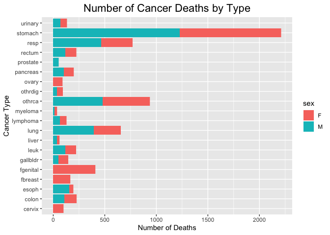

```r
tidy_hiroshima_nagasaki %>%
  filter(type_death != "alldis" & type_death != "allneo" & type_death != "allmal" & type_death != "nonleuk" & type_death != "digest") %>%
  group_by(type_death) %>%
  ggplot(aes(x = type_death, y = number_death, fill = sex)) +
  geom_bar(stat = "identity") +
  labs(title = "Number of Cancer Deaths by Type",
       x = "Cancer Type",
       y = "Number of Deaths")+
  theme(plot.title = element_text(size = rel(1.5), hjust = 0.5))+
  coord_flip()
```

This graph summarizes the number of deaths for each cancer type. Most notably, and stomach cancers were the most prevalent.

https://www.ncbi.nlm.nih.gov/pmc/articles/PMC1860129/

Japanese people more susceptible to gastritis (inflammation of protective lining of the stomach), and therefore more susceptible to stomach cancers.

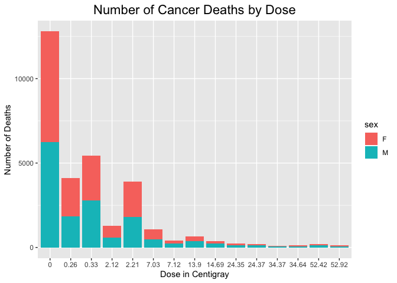

```r
hiroshima_nagasaki %>%
  group_by(dose_centigray, sex) %>%
  summarise(sum = sum(alldeaths)) %>%
  ggplot(aes(x = dose_centigray, y = sum, fill = sex)) +
  geom_bar(stat = "identity") +
  labs(title = "Number of Cancer Deaths by Dose",
       x = "Dose in Centigray",
       y = "Number of Deaths")+
  theme(plot.title = element_text(size = rel(1.5), hjust = 0.5))
```

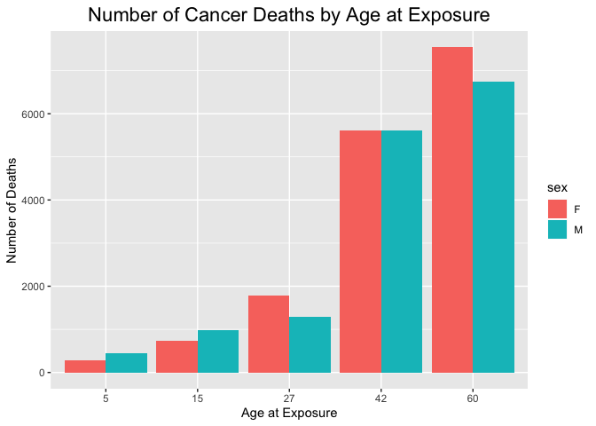

```r
hiroshima_nagasaki %>%
  group_by(sex, ageatb) %>%
  summarise(sum = sum(alldeaths)) %>%
  ggplot(aes(x = ageatb, y = sum, fill = sex)) +
  geom_bar(stat = "identity", position = "dodge") +
  labs(title = "Number of Cancer Deaths by Age at Exposure",
       x = "Age at Exposure",
       y = "Number of Deaths")+
  theme(plot.title = element_text(size = rel(1.5), hjust = 0.5))
```

There were more deaths in people who were older at the time of the bombing.

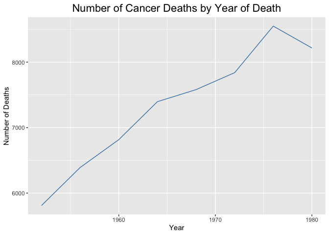

```r
tidy_hiroshima_nagasaki%>%
  mutate_at(vars(time), as.integer) %>%
  group_by(time) %>%
  summarise(sum = sum(number_death)) %>%
  ggplot(aes(x = time, y = sum)) +
  geom_line(color = "steelblue") +
  labs(title = "Number of Cancer Deaths by Year of Death",
       x = "Year",
       y = "Number of Deaths")+
  theme(plot.title = element_text(size = rel(1.5), hjust = 0.5))
```

There is a positive trend in the people who died over the years. After 1976, there was a drop in the number of deaths.

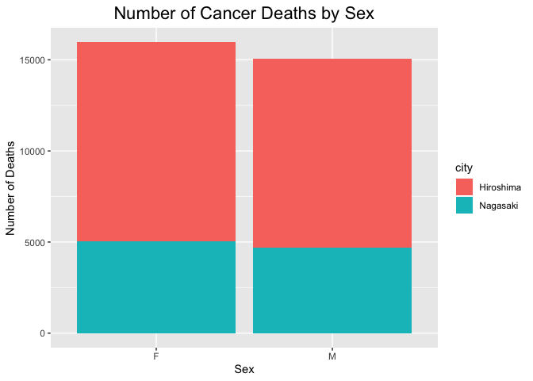

```r
hiroshima_nagasaki %>%
  group_by(sex, city) %>%
  summarise(sum = sum(alldeaths)) %>%
  ggplot(aes(x = sex, y = sum, fill = city)) +
  geom_bar(stat = "identity") +
  labs(title = "Number of Cancer Deaths by Sex",
       x = "Sex",
       y = "Number of Deaths")+
  theme(plot.title = element_text(size = rel(1.5), hjust = 0.5))
```

Females had more cancer deaths than males in total, and we are unsure of the reasons why.

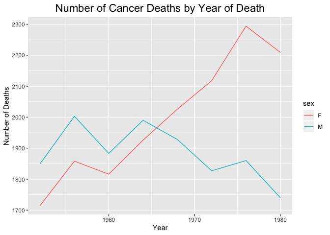

```r
hiroshima_nagasaki%>%
  mutate_at(vars(time), as.integer) %>%
  group_by(time, sex) %>%
  summarise(sum = sum(alldeaths)) %>%
  ggplot(aes(x = time, y = sum, col = sex)) +
  geom_line() +
  labs(title = "Number of Cancer Deaths by Year of Death",
       x = "Year",
       y = "Number of Deaths")+
  theme(plot.title = element_text(size = rel(1.5), hjust = 0.5))
```

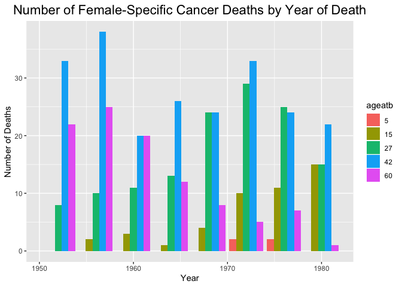

```r
tidy_hiroshima_nagasaki %>%
  mutate_at(vars(time), as.integer) %>%
  filter(type_death == "fgenital"| type_death == "cervix"| type_death == "uterus") %>%
  group_by(time, ageatb) %>%
  summarise(sum = sum(number_death)) %>%
  ggplot(aes(x = time, y = sum, fill = ageatb)) +
  geom_bar(stat = "identity", position = "dodge") +
  labs(title = "Number of Female-Specific Cancer Deaths by Year of Death",
       x = "Year",
       y = "Number of Deaths")+
  theme(plot.title = element_text(size = rel(1.5), hjust = 0.5))
```

There is a downward trend in the number of deaths among 60 year olds and an upward trend among 27 year olds and 15 year olds at the time of the bombing.

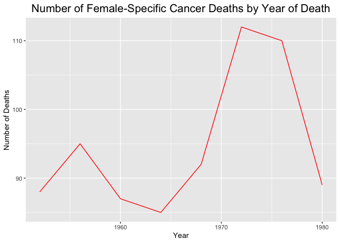

```r
tidy_hiroshima_nagasaki %>%
  mutate_at(vars(time), as.integer) %>%
  filter(type_death == "fgenital"| type_death == "cervix"| type_death == "ovary" | type_death == "fbreast") %>%
  group_by(time) %>%
  summarise(sum1 = sum(number_death)) %>%
  ggplot(aes(x = time, y = sum1)) +
  geom_line(color = "red") +
  labs(title = "Number of Female-Specific Cancer Deaths by Year of Death",
       x = "Year",
       y = "Number of Deaths")+
  theme(plot.title = element_text(size = rel(1.5), hjust = 0.5))
```

Between 1960 and 1970, there was a dip in female-specific cancer deaths (although we are not sure of why)

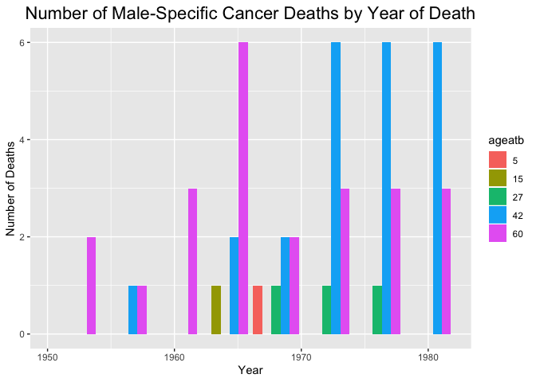

```r
tidy_hiroshima_nagasaki %>%
  mutate_at(vars(time), as.integer) %>%
   filter(type_death == "prostate") %>%
  group_by(time, ageatb) %>%
  summarise(sum = sum(number_death)) %>%
  ggplot(aes(x = time, y = sum, fill = ageatb)) +
  geom_bar(stat = "identity", position = "dodge") +
  labs(title = "Number of Male-Specific Cancer Deaths by Year of Death",
       x = "Year",
       y = "Number of Deaths")+
  theme(plot.title = element_text(size = rel(1.5), hjust = 0.5))
```

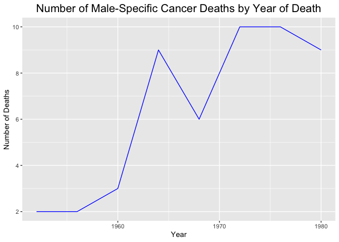

```r
tidy_hiroshima_nagasaki %>%
  mutate_at(vars(time), as.integer) %>%
  filter(type_death == "prostate") %>%
  group_by(time) %>%
  summarise(sum1 = sum(number_death)) %>%
  ggplot(aes(x = time, y = sum1)) +
  geom_line(color = "blue") +
  labs(title = "Number of Male-Specific Cancer Deaths by Year of Death",
       x = "Year",
       y = "Number of Deaths")+
  theme(plot.title = element_text(size = rel(1.5), hjust = 0.5))
```

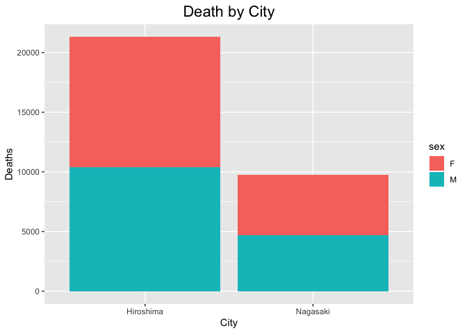

```r
hiroshima_nagasaki %>%
  group_by(sex, city) %>%
  summarise(sum = sum(alldeaths)) %>%
  ggplot(aes(x=city, y = sum, fill = sex))+
  geom_bar(stat="identity")+
  labs(title = "Death by City", x= "City", y= "Deaths")+
  theme(plot.title = element_text(size = rel(1.5), hjust = 0.5))
```

There were many more deaths in hiroshima than nagasaki, and this is because the population of Hiroshima was much bigger. Hiroshima = 350,000, Nagasaki = 263,000